# Solutions to Homework #3 (Matrices in R)

```r
X <- as.matrix(read.table("horn.txt"))
```

First we need the transpose of `X` and to standardize to have column sums equal to one,

```r
(X <- t(X)/100)
```

```
##     Big-toothed aspen Gray birch Sassafras Blackgum Sweetgum White oak
## BTA              0.03       0.00      0.03     0.01     0.00      0.00
## GB               0.05       0.00      0.01     0.01     0.00      0.00
## SF               0.09       0.47      0.10     0.03     0.16      0.06
## BG               0.06       0.12      0.03     0.20     0.00      0.07
## SG               0.06       0.08      0.06     0.09     0.31      0.04
## WO               0.00       0.02      0.03     0.01     0.00      0.10
## OK               0.02       0.08      0.10     0.07     0.07      0.07
## HI               0.04       0.00      0.12     0.06     0.07      0.03
## TU               0.02       0.03      0.00     0.10     0.05      0.14
## RM               0.60       0.17      0.37     0.25     0.27      0.32
## BE               0.03       0.03      0.15     0.17     0.07      0.17
##     Red oaks Hickories Tulip tree Red maple Beech
## BTA     0.00      0.00       0.00      0.00  0.00
## GB      0.00      0.00       0.00      0.00  0.00
## SF      0.02      0.01       0.02      0.13  0.00
## BG      0.11      0.03       0.04      0.10  0.02
## SG      0.07      0.01       0.04      0.09  0.01
## WO      0.06      0.03       0.00      0.02  0.01
## OK      0.08      0.13       0.11      0.08  0.01
## HI      0.08      0.04       0.07      0.19  0.01
## TU      0.08      0.09       0.09      0.03  0.08
## RM      0.33      0.49       0.29      0.13  0.06
## BE      0.17      0.17       0.34      0.23  0.80
```

Long-run composition using a for loop:

```r
n <- n0 <- rep(1,ncol(X))
for(i in 1:100) n <- X%*%n
longrun.for <- n
```

using the explicit eigen-based closed form solution,

```r
Xeig <- eigen(X)
S <- Xeig$vectors
d <- Xeig$values
D <- diag(d, length(d), length(d))
n <- rep(1,ncol(X))
longrun.eigen <- Re(S%*%(D^100)%*%solve(S)%*%n0)
```

and using the `%^%` operator,

```r
library(expm)
longrun.expm <- (X%^%100)%*%n0
```

Create normalize function,

```r
normalize <- function(x) x/sum(x)
```

so that we can compare dominant eigenvector, with the three other calculations of the long-run composition,

```r
cbind(normalize(longrun.for),
      normalize(longrun.eigen),
      normalize(longrun.expm),
      Re(normalize(S[,1])))
```

```
##          [,1]      [,2]      [,3]      [,4]
## BTA 0.0017105 0.0017105 0.0017105 0.0017105
## GB  0.0009629 0.0009629 0.0009629 0.0009629
## SF  0.0390876 0.0390876 0.0390876 0.0390876
## BG  0.0486536 0.0486536 0.0486536 0.0486536
## SG  0.0494755 0.0494755 0.0494755 0.0494755
## WO  0.0163310 0.0163310 0.0163310 0.0163310
## OK  0.0494669 0.0494669 0.0494669 0.0494669
## HI  0.0589164 0.0589164 0.0589164 0.0589164
## TU  0.0703171 0.0703171 0.0703171 0.0703171
## RM  0.1633225 0.1633225 0.1633225 0.1633225
## BE  0.5017559 0.5017559 0.5017559 0.5017559
```

Here’s the plot,

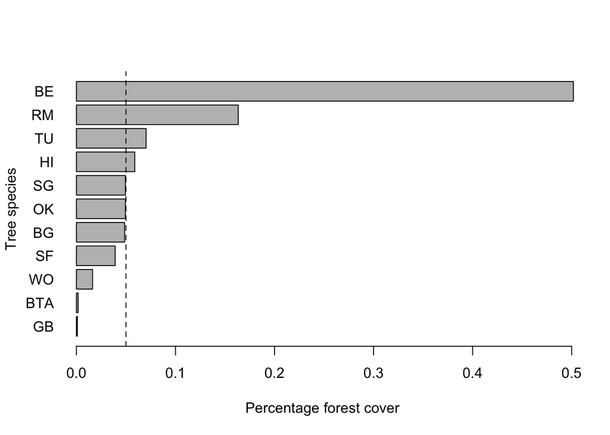

```r
barplot(sort(normalize(longrun.expm)[,1]),
        horiz = TRUE, las = 1,
        xlab = "Percentage forest cover",
        ylab = "Tree species")
abline(v = 0.05, lty = 2)
```

The number of species that will be present at frequencies greater than 5% is,

```r
sum(normalize(longrun.expm) > 0.05)
```

```
## [1] 4
```

The last ‘bonus’ question is a bit of a trick question: is the origin a stable fixed point? The students should recognize that this is a linear system, which has a stable fixed point at the origin whenever all of the eigenvalues have modulus less than one. So their first step should be:

```r
Mod(eigen(X)$values)
```

```
##  [1] 1.00000 0.63657 0.24043 0.19354 0.19354 0.12769 0.06335 0.06335
##  [9] 0.03774 0.03774 0.01150
```

or maybe,

```r
Mod(eigen(X)$values) < 1
```

[output not shown]

If they are *really* cleaver they may say that the system is neutrally stable along the dominant eigenvector. That is, the time-dependent solution of the model $\mathbf{n}(t+1) = \mathbf{Xn}(t)$ can be writen as a linear combination of eigenvectors, $\mathbf{s}_i, i = 1,...$, $\mathbf{n}(t) = \sum_i d_i^t c_i \mathbf{s}_i$ where $d_i$ are eigenvalues and $c_i$ are determined from initial conditions. Therefore, if $d_1 = 1$ and $|d_i|<1$ for all other eigenvalues, the system will return to, $\mathbf{n} \approx c_i \mathbf{s}_i$ which is a constant dependent on initial conditions. Therefore, perturbations to the system will only result in a return of the state variable $\mathbf{n}$ to this constant multiple of the dominant eigenvector (i.e. a return to a one dimensional space). In other words the system is neutrally stable along the dominant eigenvector.

Cleaver students might also notice that $\mathbf{n}(t)$ is a fixed point if $\mathbf{n}(t+1) = \mathbf{n}(t)$. So $\mathbf{In} = \mathbf{Xn}$ where $\mathbf{I}$ is the identity matrix, which implies that $\mathbf{0} = (\mathbf{X-I})\mathbf{n}$. Then they may notice that $\mathbf{X-I}$ is not invertible in this case because,

```r
XminusI <- X - diag(1,nrow(X),ncol(X))
try(solve(XminusI))
```

[output not shown]

```r
ncol(X)-qr(XminusI)$rank
```

```
## [1] 1
```

that satisfies the definition of fixed points above.